# Ejemplos de Estadística Descriptiva con R

Salvador Díaz Maldonado

2025-01-10

https://rpubs.com/FabioScielzoOrtiz/Estadistica_Descriptiva_en_R

# Ejemplo 1.

Determinar, utilizando los 25 datos *x*, *y* de la siguiente tabla, los parámetros de localización, dispersión y sesgo.

## Datos *x* y *y*

| x | y |
| --- | --- |
| 1.096 | 9.966 |
| -0.852 | 0.900 |
| 0.635 | 1.122 |
| 1.079 | 1.503 |
| -2.630 | 0.939 |
| 0.421 | 0.705 |
| 0.584 | 28.527 |
| -0.364 | 0.332 |
| 2.264 | 2.130 |
| -0.605 | 0.825 |

[output cut: 15 more lines]

## Para la variable *x*

A continuación se muestra un histograma y un diagrama de caja de *x*.

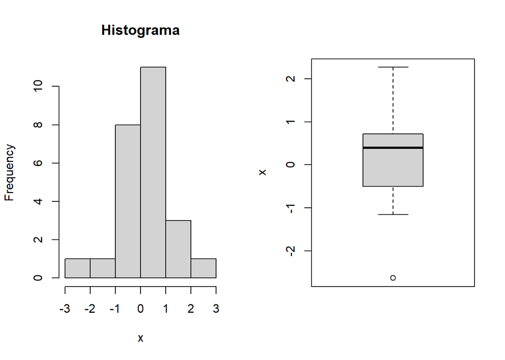

Los valores de los cuantiles del diagrama de caja son:

```
##     0%    25%    50%    75%   100%
## -2.630 -0.504  0.395  0.718  2.264
```

*Hay un valor atípico (-2.630) fuera del intervalo de los cuantiles máximo y mínimo.*

```
## [1] Cuantil máximo = 2.551 Cuantil mínimo = -2.337
```

*Del histograma y del diagrama de bloques (en este particularmente por el punto atípico), se observa diferencia entre la media y la mediana y un sesgo hacia la izquierda. Se puede confirmar usando la curva de densidad y el diagrama de caja en el histograma.*

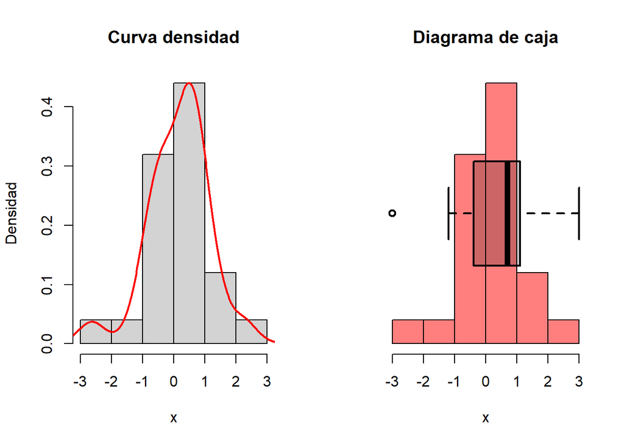

### Medidas de localización o de tendencia central

```
## [1] Media aritmética (medida clásica) = 0.16 , Mediana (medida resistente) = 0.395
```

### Otras medidas de tendencia central

```
## [1] Media_Geométrica = NaN , Media Trucada 0.25 = 0.229
```

*La media está influenciada por el valor atípico (-2.630). La mediana está alejada de la media; lo que refleja un sesgo hacia la izquierda (la media menor que la mediana). La media truncada (al igual que la mediana) no está tan influenciada por el valor atípico, como si lo está la media.*

### Medidas de dispersión o variabilidad.

*Medidas clásicas*:

```
## [1] Varianza = 0.94031 , Desv. Est. = 0.96969
```

*Medidas resistentes*:

```
## [1] Rango Intercuartil = 1.23 , Desviación absoluta media =  0.621
```

Otra medida de variabilidad es el coeficiente de variación:

```
## [1] Coef. de variación = 6.042
```

*Debido a la asimetría de la muestra (por la influencia del valor atípico), la desviación estándar y el rango intercuartil son mayores que la desviación absoluta mediana.*

### Medidas de simetría o de sesgo.

```
## [1] Sesgo (medida clásica) = -0.6347
```

```
## [1] Sesgo de cuartil p50, p75 (medida resistente) = -0.4659
```

Se verifica el sesgo hacia la izquierda.

### Otras medidas de simetría o sesgo

```
## [1] Cuartil sesgado recortado = -0.2378
```

===================================================================

## Para la variable y

A continuación se muestra un histograma y un diagrama de caja de *y* .

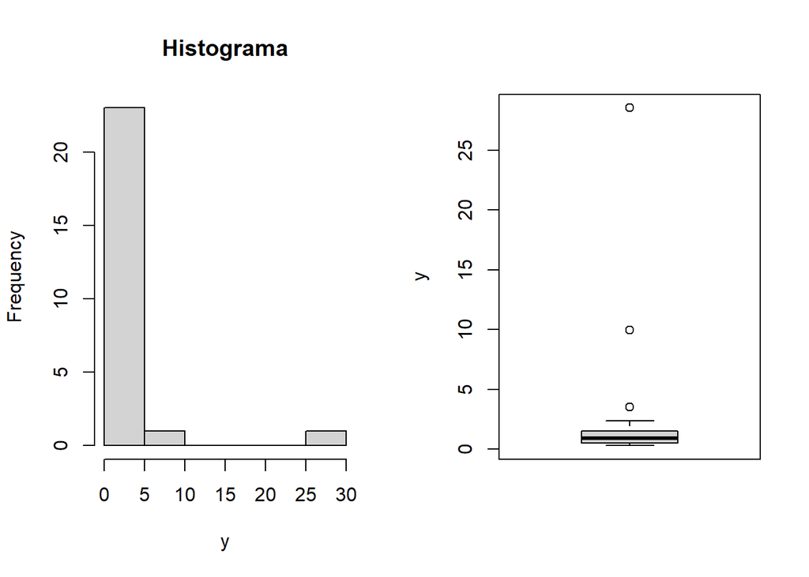

Los valores de los cuantiles del diagrama de caja son:

```
##     0%    25%    50%    75%   100%
##  0.305  0.536  0.909  1.503 28.527
```

Se tienen tres valores atípicos, 3.528, 9.966 y 28.527, mayores que el cuantil máximo (2.9535).

```
## [1] Cuantil máximo = 2.9535 Cuantil mínimo = -0.9145
```

Del histograma y del diagrama de bloques, se observa mucha diferencia entre la media y la mediana y un sesgo hacia la derecha, debido a los puntos atípicos detectados. Se puede confirmar usando la curva de densidad y el diagrama de caja en el histograma.

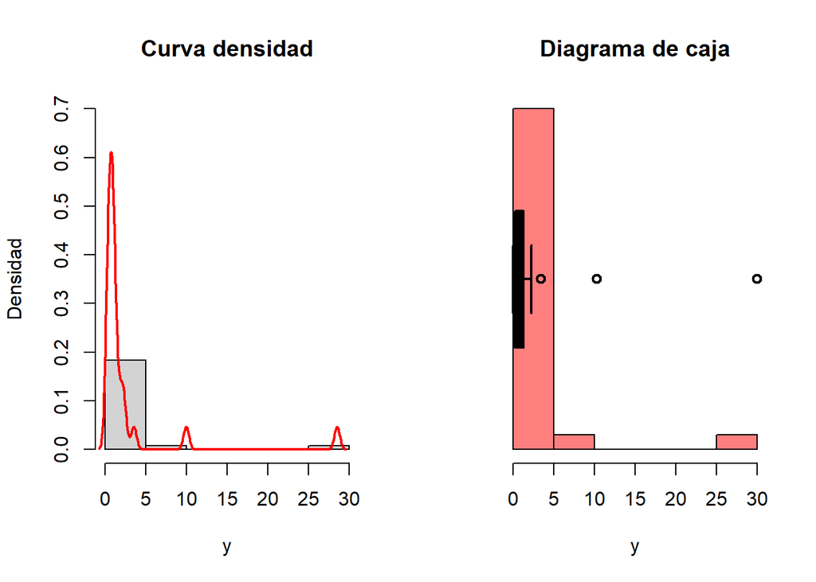

### Medidas de localización o de tendencia central

```
## [1] Media aritmética (medida clásica) = 2.52 , Mediana (medida resistente) = 0.909
```

*La mediana está alejada de la media; lo que refleja un sesgo hacia la derecha (la media mayor que la mediana).*

### Otras medidas de resistencia central

```
## [1] Media_Geométrica = 1.08 , Media Trucada 0.25 = 0.939
```

*La media geométrica y la media truncada, al igual que la mediana, resisten el efecto de los valores atípicos.*

### Medidas de dispersión o variabilidad.

*Medidas clásicas*:

```
## [1] Varianza = 33.099 , Desv. Est. = 5.7532
```

*Medidas resistentes*:

[output not shown]

Otra medida de variabilidad es el coeficiente de variación:

```
## [1] Coef. de variación = 2.286
```

### Medidas de simetría o de sesgo.

```
## [1] Sesgo (medida clásica) = 4.256
```

```
## [1] Sesgo de cuartil p50, p75 (medida resistente) = 0.3349
```

*Se verifica el sesgo hacia la derecha.*

### Otras medidas de simetría o sesgo

```
## [1] Cuartil sesgado recortado = 0.8029
```

=====================================================================

**Como conclusión general se puede decir que ambos conjuntos de datos tienen una dispersión importante, y que el segundo conjunto está mucho más sesgado que el primero. Lo que hace sospechar que en este último no existe normalidad. Este punto será comprobado en el primer ejemplo de ESTADÍSTICA INFERENCIAL**

=====================================================================